# Effects of loan Characteristics on Their Prosper Rating

## by EMMANUEL NCUBE

## Investigation Overview

In this investigation, I wanted to look at the characteristics of loans that could be used to determine Prosper rating (alpha) which was adopted after July 2009. I focus on just the influence of the prosper and credit scores, estimated loss on prosper rating (alpha).

## Dataset Overview

The data consists of information regarding a dataset containing prosper loans and attributes for approximately 113,937 loans made to its clients, including Prosper Rating (Alpha), Prosper and Credit Scores, Estimated Loss, and other features. Only loans made after July 2009 were included, when the Prosper Rating (Alpha) system was adopted.

#### Distribution of Prosper Rating

Prosper Ratings, from lowest-risk to highest-risk, are labeled AA, A, B, C, D, E, and HR ("High Risk"). Most prosper clients' prosper ratings are C followed by B, A, D, E and HR. Most borrowers are home owners and the majority of them are employed and full time.

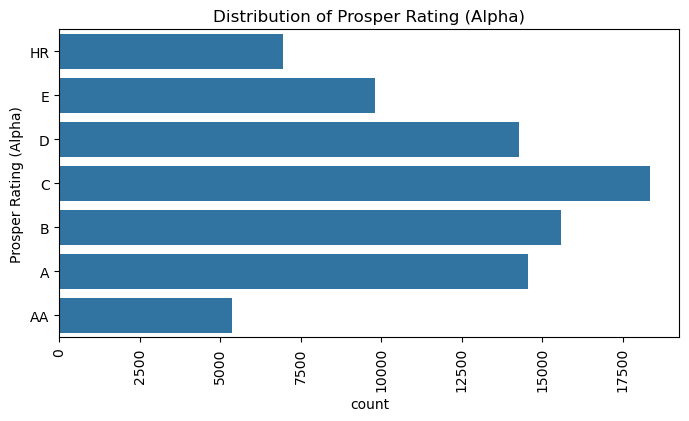

#### Distribution of Credit Score

The Credit Score looks slightly normally distributed. The most frequent Credit Score range: (660.0 , 670.0).

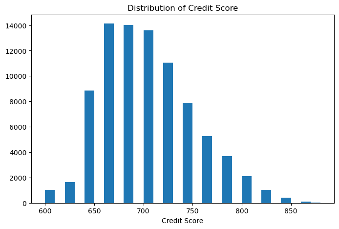

#### Distribution of Estimated Loss

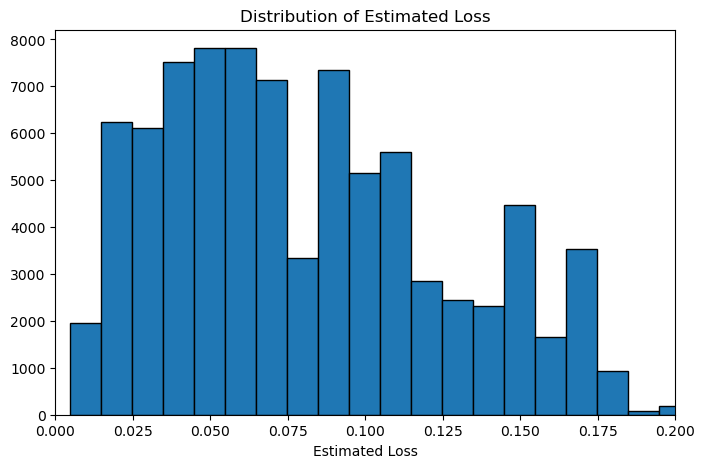

#### Distribution of Prosper Score

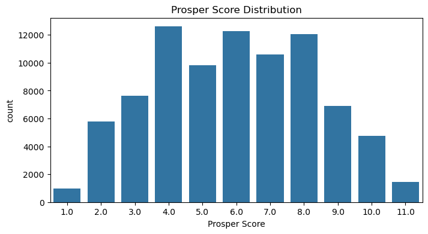

#### Credit Score and Prosper Score by Prosper Rating

We can see that low prosper rated loans Prosper have low Credit and Prosper Scores.

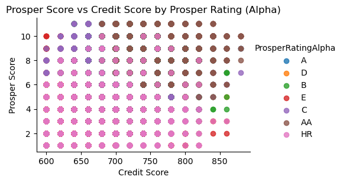

#### Prosper Score vs Credit Score by Estimated Loss

Higher Credit Score and Prosper scores tend to go with lower estimated losses.

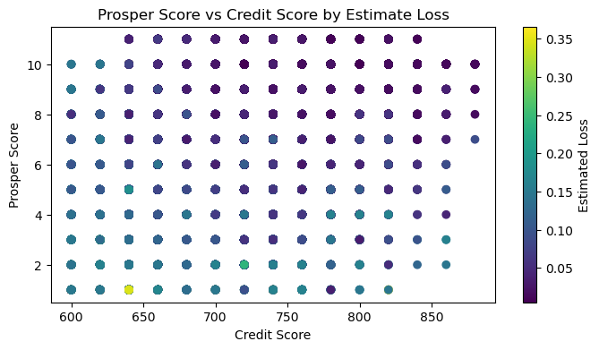

#### Prosper Rating and Estimated Loss

After restricting estimated loss to 0.2, we can clearly see that the higher the estimated loss the low the prosper rating.

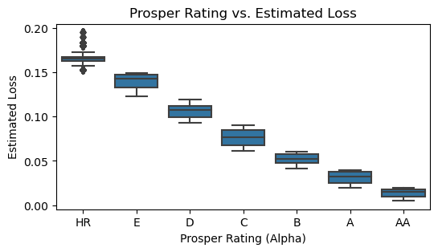

## Conclusion

> Generally, the higher the credit and prosper scores, the lower the estimated loss and the higher the prosper rating. Estimated Loss has a major effect on prosper rating (alpha) and estimated loss is determined by prosper score and credit score.